# Índice de Transparência nos Ministérios Públicos

## Órgãos que não estão sendo coletados

Os órgãos abaixo não estão sendo coletados devido a problemas de disponíbilidade e acesso causados pelos próprios órgãos (mudança de formato, alta complexidade para extração, inconsistências, etc.)

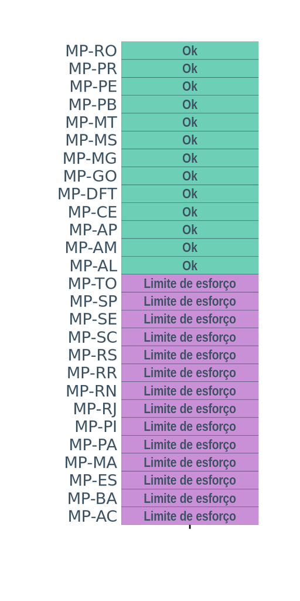

## Índice de Facilidade

- Necessidade de login
- Necessário captcha
- Formato de acesso
- Manteve consistência no formato
- Formato estritamente tabular

### Necessidade de login

**Definição**: A necessidade de fornecimento de informações pessoais e autenticação para acesso dos dados. Requerer é o pior caso.

**Valores**:

- $1,00$: não requer login
- $0,00$: requer login

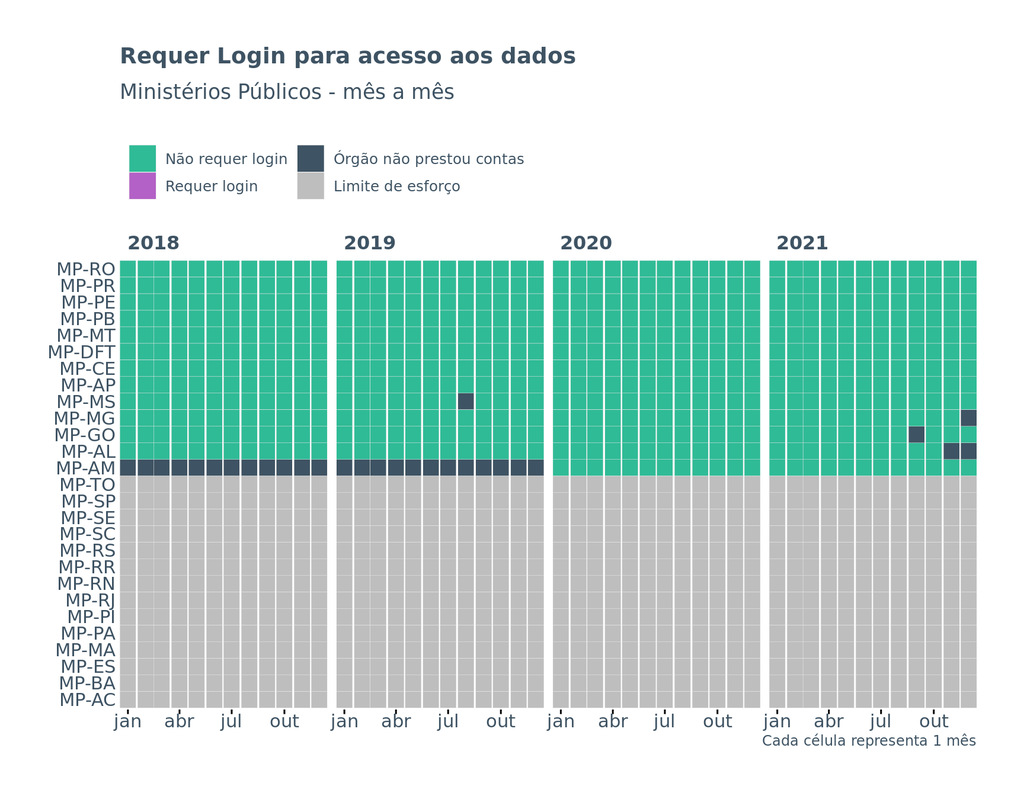

### Necessário Captcha

**Definição**: Verificação se o acesso está sendo feito por humanos.

**Valores**:

- $1,00$: não requer captcha
- $0,00$: requer captcha

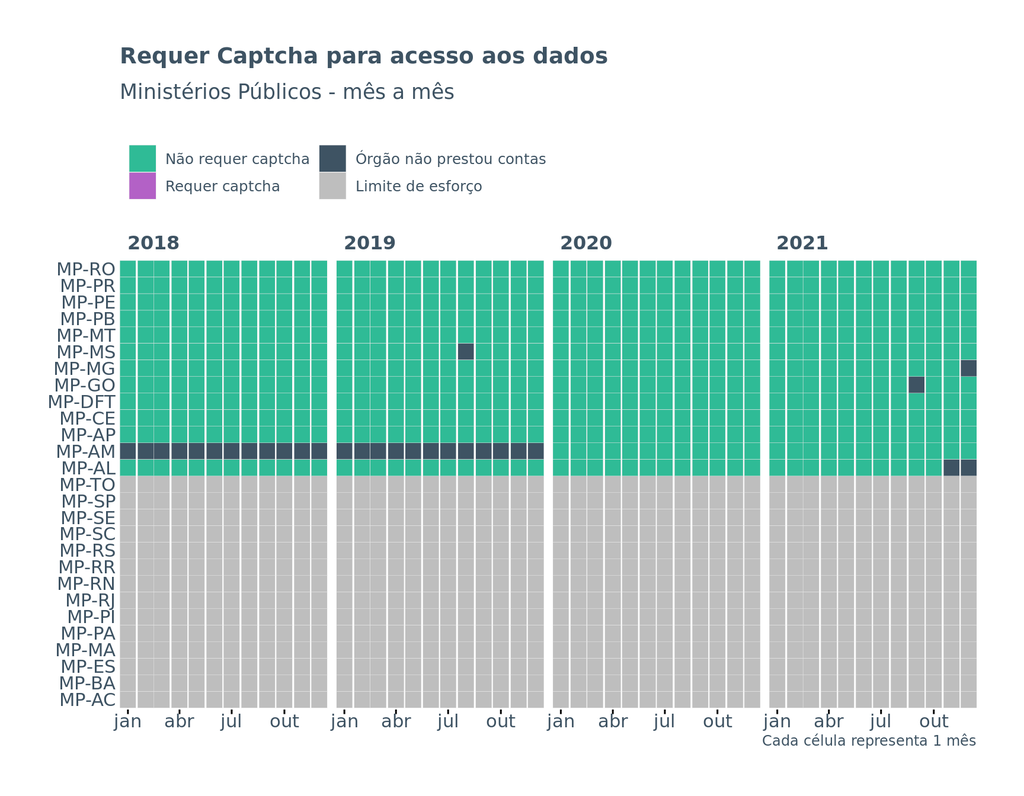

### Acesso

**Definição**: Se é possível acessar os dados programaticamente através de URLs que seguem boas práticas, se é necessário raspar os dados de maneira fácil (pois páginas e URLs têm boas práticas de estrutura), se é necessário raspagem complexa ou se é necessário simular um usuário usando um navegador (pior caso).

**Valores**:

- $1,00$: o acesso é feito de forma **DIRETA**, através de URLs que seguem boas práticas
- $0,50$: o acesso é **AMIGAVEL PARA RASPAGEM**
- $0,25$: o acesso **NÃO É AMIGAVEL PARA RASPAGEM**
- $0,00$: é **NECESSÁRIO SIMULAÇÃO DE USUÁRIO** para acesso

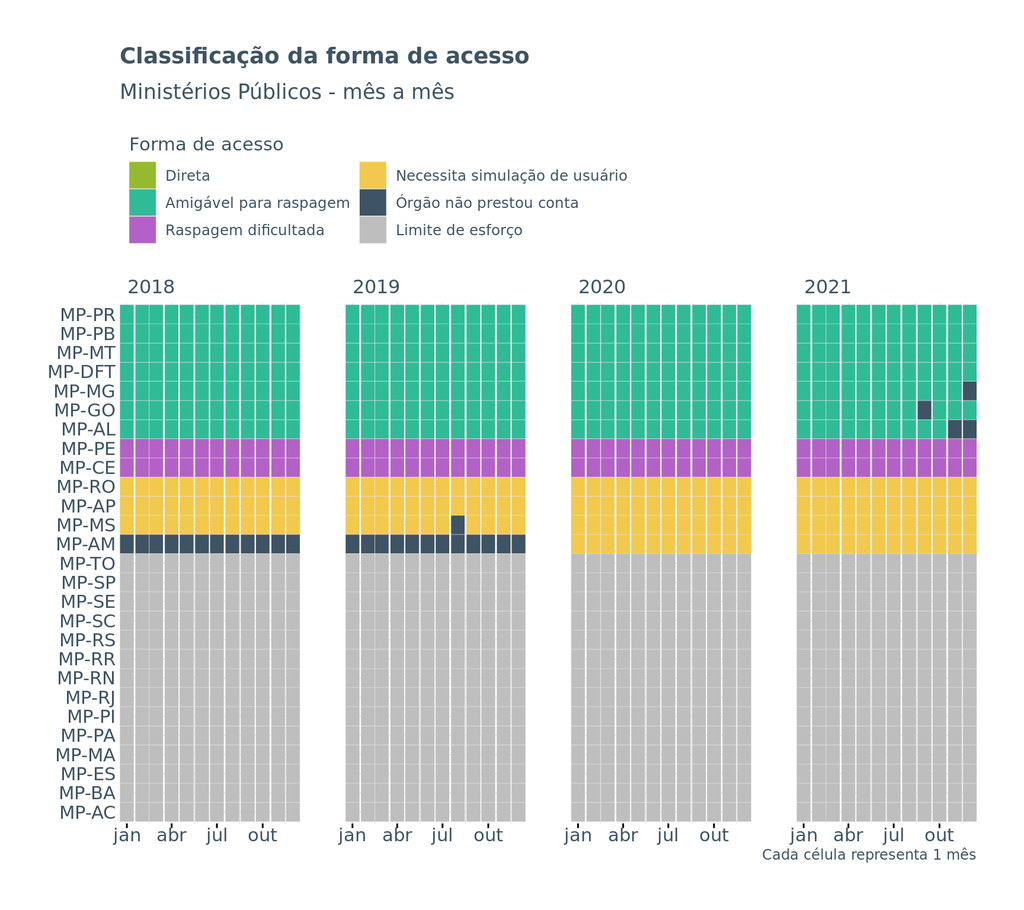

### Manteve consistência do formato

**Definição**: Esse campo captura se houve mudanças no formato como os dados que foram disponibilizados.

**Valores**:

- $1,00$: quando o formato é consistente
- $0,00$: quando o formato não é consistente

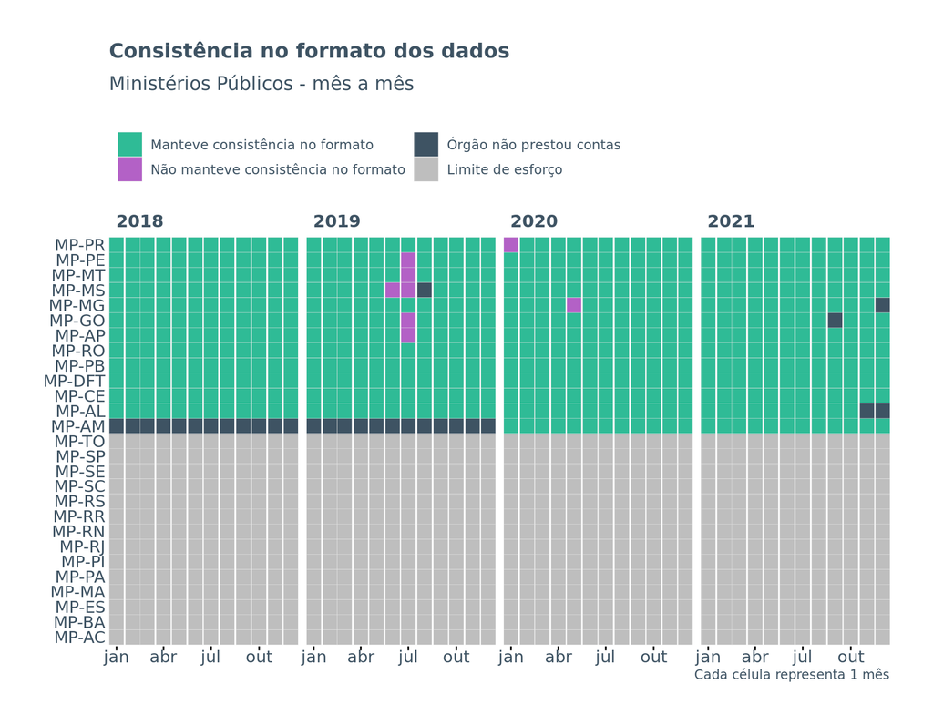

### Formato estritamente tabular

**Definição**: Os dados estão em formato que permite importação direta em software de análise ou precisam ser processados primeiro (por ex. por estarem em um doc ou pdf).

**Valores**:

- $1,00$: quando o formato é estritamente tabular
- $0,00$: quando o formato não é estritamente tabular

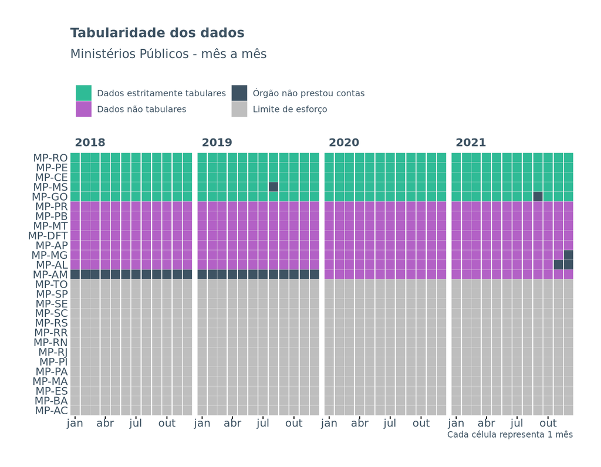

## Índice de Completude

- Nome e matrícula
- Lotação
- Cargo
- Remuneração básica
- Outras receitas
- Detalhamento de despesas

### Nome e matrícula

**Definição**: Nome e número de identificação do funcionário

**Valores**:

- $1,00$: possui ambos os atributos
- $0,00$: não possui um dos atributos

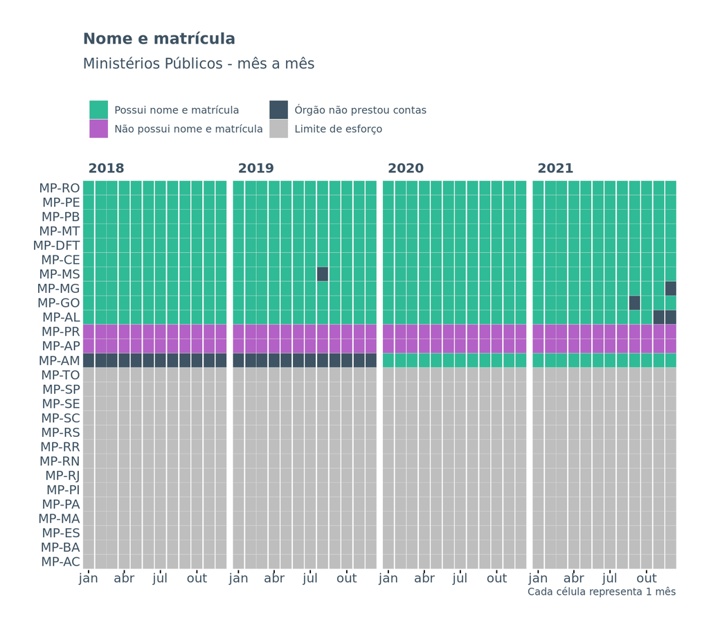

### Lotação

**Definição**: local onde o sercidor exerce as atribuições e responsabilidades do cargo público.

**Valores**:

- $1,00$: possui o atributo lotação
- $0,00$: não possui o atributo lotação

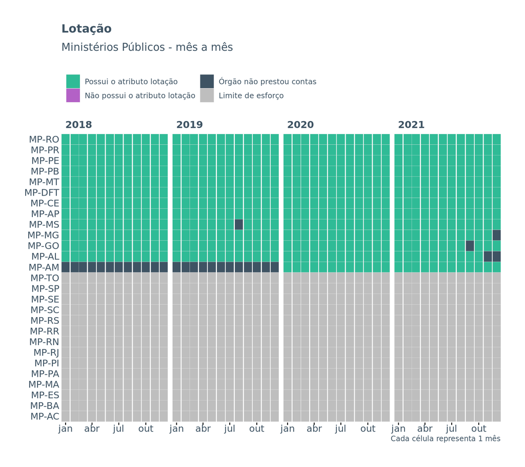

### Cargo

**Definição**: função que o servidor exerce no órgão.

**Valores**:

- $1,00$: possui o atributo cargo
- $0,00$: não possui o atributo cargo

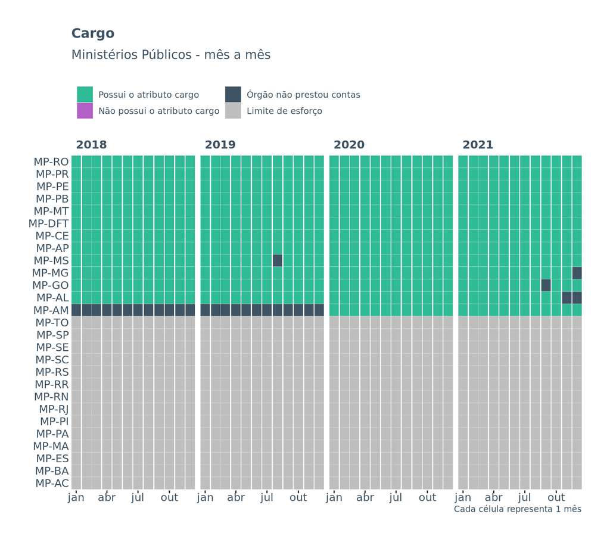

### Remuneração básica

**Definição**: para os Ministérios Públicos o valor da remuneração básica é composto pela soma do valor da remuneração do Cargo Efetivo e o valor correspondente a outras verbas remuneratórias, legais ou judiciais.

**Valores**:

- $1,00$: apresenta remuneração básica **detalhada**
- $0,50$: apresenta remuneração básica **sumarizada**
- $0,00$: não apresenta remuneração básica

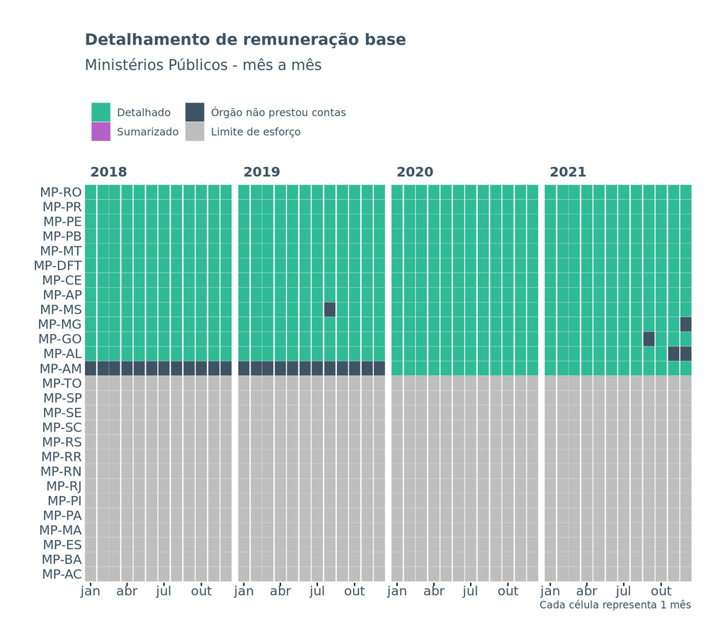

### Despesas

**Definição**: valor correspondentes a descontos obrigatórios como: Contribuição Previdenciária, Imposto de Renda e Retenção por Teto Constitucional

**Valores**:

- $1,00$: apresenta despesas **detalhadas**
- $0,50$: apresenta despesas **sumarizadas**
- $0,00$: não apresenta despesas

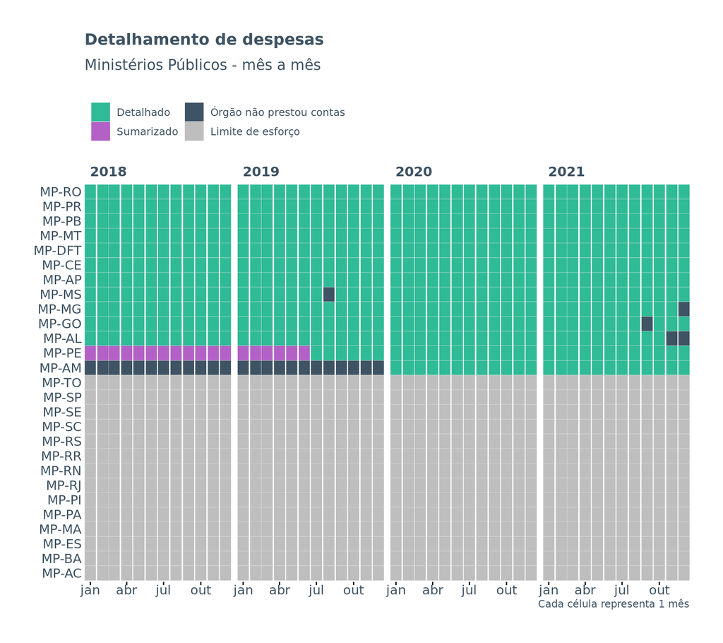

### Outras remunerações

**Definição**: ínclui remuneração eventual ou temporária, tais como: função de confiança ou cargo em comissão, gratificação natalina, férias constitucionais, abono permanência, insalubridade, bem como as indenizações, por exemplo: pecúnias ou auxílios como: alimentação, saúde, creche, moradia, natalidade.

**Valores**:

- $1,00$: apresenta outras receitas **detalhadas**
- $0,50$: apresenta outras receitas **sumarizadas**
- $0,00$: não apresenta outras receitas

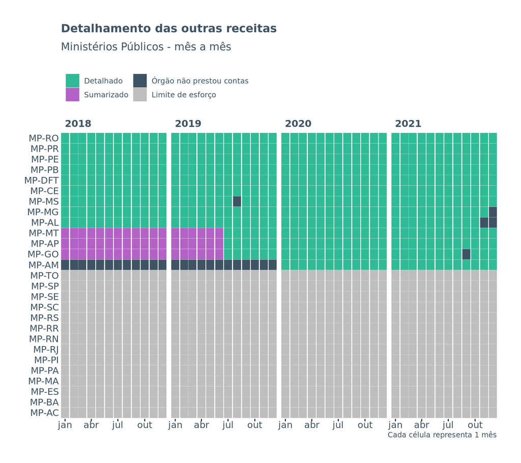

## Pontuações agregadas

### Pontuação média - Facilidade (2018-2021)

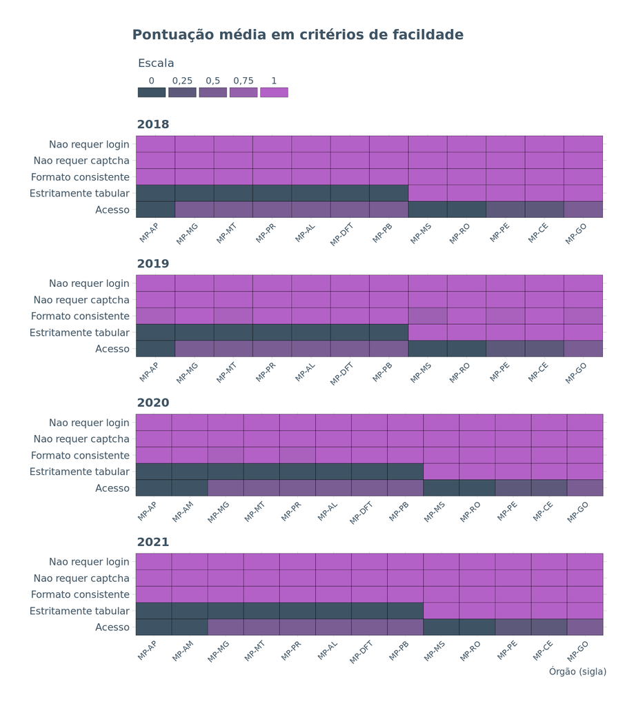

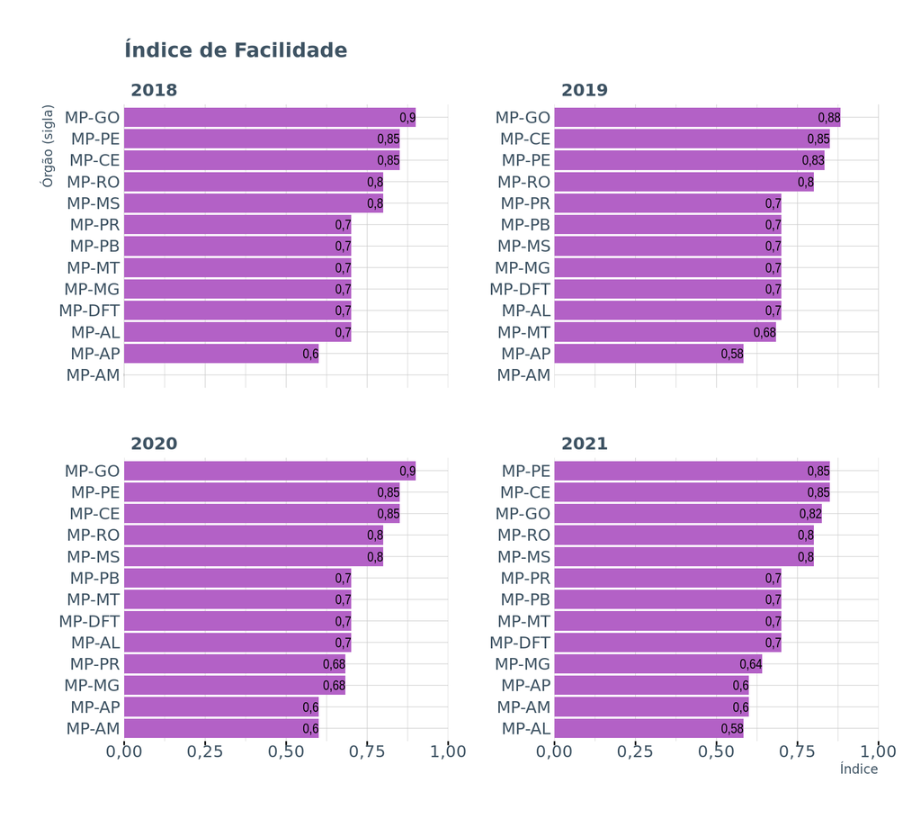

### Pontuação média - Completude (2018-2021)

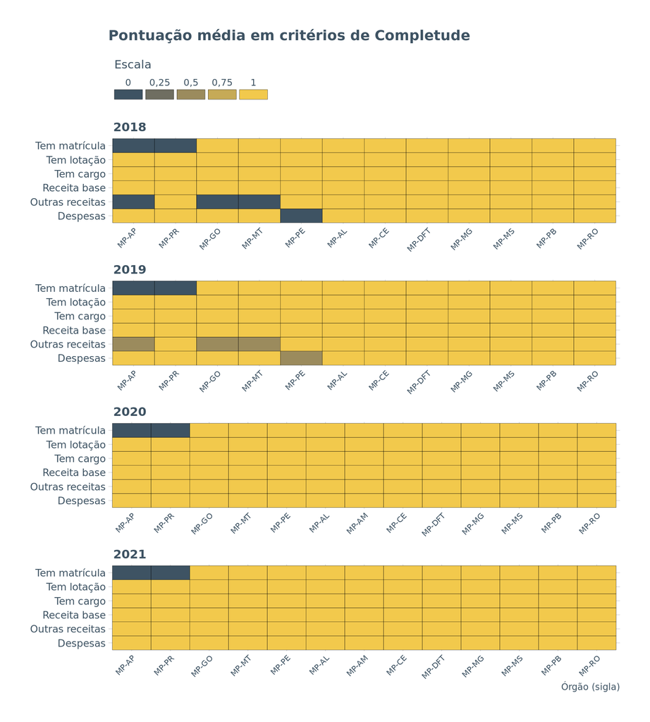

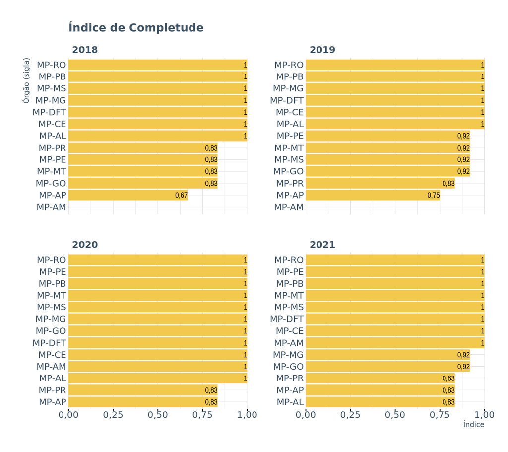

### Pontuação média - índice de Transparência

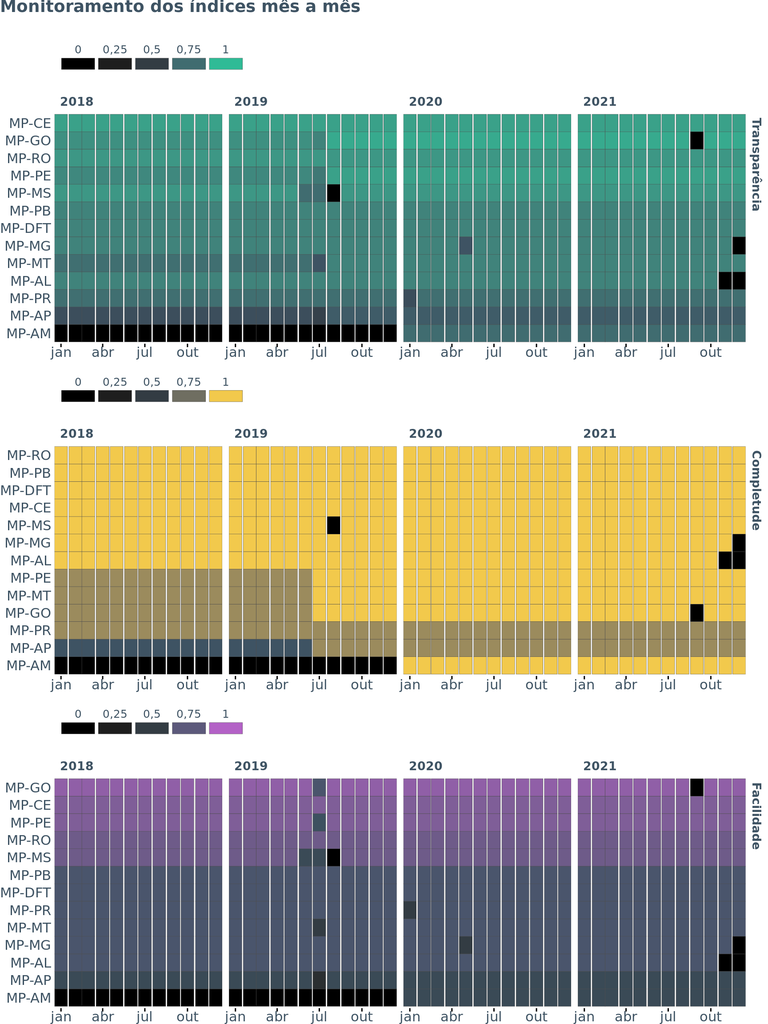

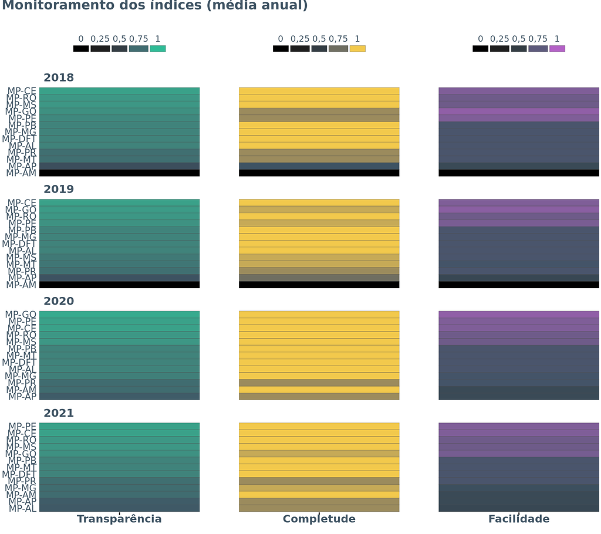

### Pontuação média de todos os índices por órgão

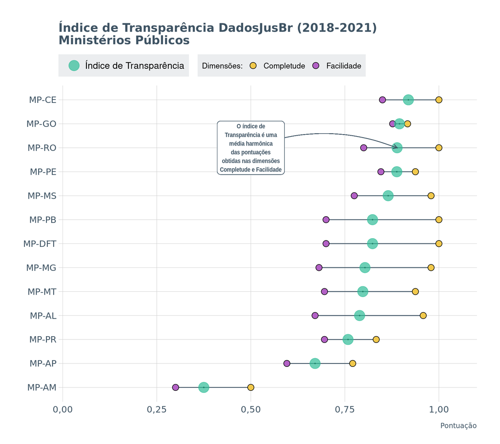